# Display dye coverage at the 8 slices

This notebook displays the processed images where the blue dye has been identified.

General info on the tracer experiment is in the `readme.md` file in the home folder. Details about the blue dye image processing are in the `README_Dye_Images.txt` file.

```python
import pandas as pd
import matplotlib.pyplot as plt
import numpy as np
from PIL import Image
import os.path

# a few options
export_to_csv = 0
summary_filename = "summary_profiles.csv"
```

## Re-export the summary profile at each slice, if needed

This can be useful if one want to compute different statistics than just the dye coverage fraction at each depth

```python
# check if data needs to be exported
if export_to_csv == 1:

    # Read and process the slice files
    flist = ['Slice1L_data.txt','Slice1R_data.txt',
            'Slice2L_data.txt','Slice2R_data.txt',
            'Slice3L_data.txt','Slice3R_data.txt',
            'Slice4L_data.txt','Slice4R_data.txt']
    dx = 0.1 #pixel size in cm

    concat_series = []
    # loop through all the slices and compute a profile
    for fname in flist:

        # import, process and append the slice data
        relpath = os.path.join("Individual Slices Data", fname) # build path to a slice
        M = np.loadtxt(relpath, dtype='i', delimiter=',')
        profile = pd.Series(M.sum(axis=1)/M.shape[1], name = fname[0:7])
        concat_series.append(profile)

    # combine all slice data into a dataframe
    df = pd.concat(concat_series,axis=1)
    df["depth"] = np.round(dx*np.arange(1,df.shape[0]+1),1)

    # export to csv file
    df.iloc[:, [8,0,1,2,3,4,5,6,7]].to_csv(summary_filename,index=False)
```

## Overview of all the processed images

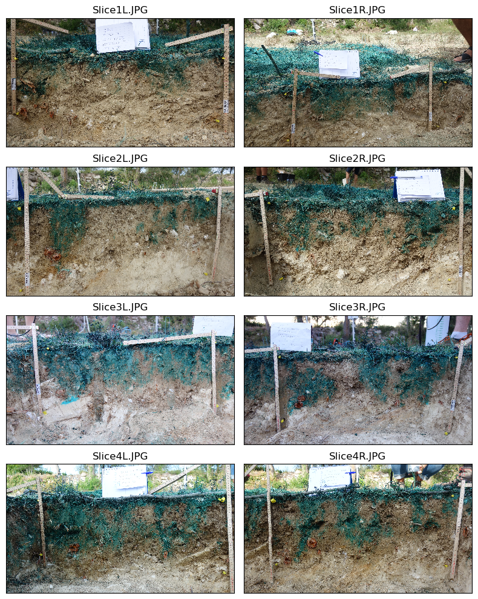

```python
# Display the original images
flist = ['Slice1L.JPG','Slice1R.JPG',
        'Slice2L.JPG','Slice2R.JPG',
        'Slice3L.JPG','Slice3R.JPG',
        'Slice4L.JPG','Slice4R.JPG']

# fig settings
rows, cols = 4, 2
fig, axs = plt.subplots(rows, cols, figsize=(8, 10))

# loop through all the slices and show them
concat_series = []
for fname, ax in zip(flist, axs.flatten()):

    # import and show the images
    relpath = os.path.join("Original photos", fname) # build path to a slice
    M = Image.open(relpath)
    ax.imshow(M, interpolation = 'none')
    ax.axes.xaxis.set_visible(False)
    ax.axes.yaxis.set_visible(False)
    ax.set_title(fname)
plt.tight_layout()
```

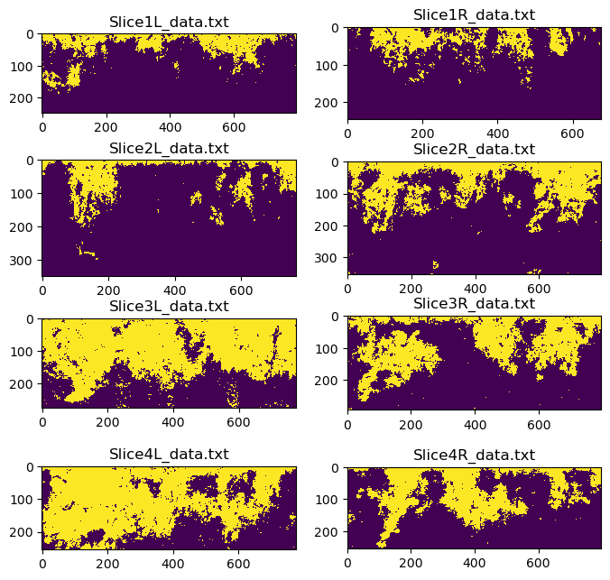

```python
# Display the processed slice files
flist = ['Slice1L_data.txt','Slice1R_data.txt',
        'Slice2L_data.txt','Slice2R_data.txt',
        'Slice3L_data.txt','Slice3R_data.txt',
        'Slice4L_data.txt','Slice4R_data.txt']
dx = 0.1 #pixel size in cm

# fig settings
rows, cols = 4, 2
fig, axs = plt.subplots(rows, cols, figsize=(8, 8))

# loop through all the slices and show them
concat_series = []
for fname, ax in zip(flist, axs.flatten()):

    # import and show the processed slices
    relpath = os.path.join("Individual Slices Data", fname) # build path to a slice
    M = np.loadtxt(relpath, dtype='i', delimiter=',')
    ax.imshow(M, interpolation = 'none')
    ax.set_title(fname)
```